# Pagedown

Brenda Georgina Tafoya Olvera

27/2/2020

Pagedwon es un paquete que forma parte del ecosistema de R Markdown.

Crea documentos PDF a partir de R Markdown con ayuda de HTML y CSS.

[figure not shown]

# Ventajas

- Es altamente accesible, pues solo necesita un navegador web moderno (por ejemplo, Google Chrome) para generar un PDF.
- No es necesario instalar LaTeX para obtener PDFs de buena calidad.
- Tiene una interfaz amigable.
- Es eficiente.

# Desventajas

- El paquete es reciente, salió en 2019, por lo que aún está en etapa experimental.
- Conocimiento previo de ambiente de R Markdown.
- Funciones extra para convertir archivos a PDF.

### Instalación recomendada (desde Github)

```r
remotes::install_github('rstudio/pagedown')
```

### ¿Cómo empezar a usarlo?

- Desde RStudio ve a File->New File->R Markdown-> From Template y busca y selecciona cualquiera de los templates de pagedown en la lista de opciones. Guardar como un archivo .Rmd como es usual y empezar a editar tu documento.

[figure not shown]

### ¿Qué se puede hacer con Pagedown?

- [Documentos HTML paginados](https://bookdown.org/yihui/rmarkdown/)
- [Tésis](https://pagedown.rbind.io/thesis-paged)
- [Revistas científicas](https://pagedown.rbind.io/jss-paged)
- [Tarjetas de presentación (Business Cards)](https://pagedown.rbind.io/business-card)
- [Currículum](https://pagedown.rbind.io/html-resume)
- Pósters ([infografías](https://pagedown.rbind.io/poster-relaxed) y [científicos](https://pagedown.rbind.io/poster-jacobs))
- [Cartas](https://pagedown.rbind.io/html-letter)
- Libros

### ¿Cómo rellenar los templates?

- En general, se rellenan de la misma forma en la que se hace un R Markdown, entonces se recomienda tener siempre a la mano la [R markdown guide](https://bookdown.org/yihui/rmarkdown/), si no, préguntale a Google.
- Se pueden incluir tablas, ecuaciones cinentíficas (tal y como lo harías en LaTeX), chunks de código de R, imágenes e incluso GIFs.

### ¿Cómo obtener e imprimir tu archivo en PDF?

- Una ventaja y desventaja grnade de este paquete es la renderización y la conversión a PDF sin ningún componente de LaTeX, pues aunque el botón de knit funciona no convierte tu archivo directamente a PDF. Abre la usual ventana de R con tu documento en HTML, sin embargo, cuadno le das en abrir en el explorador te abre una página en blanco.
- Para solucionar este problema se requiere la ayuda del paquete Xaringan y su función “Infinite Moon Reader”.

```r
install.packages("xaringan")
xaringan::inf_mr("archivo.Rmd")
```

- Otra forma de obtener el archivo en PDF es usar la función chrome_print

```r
pagedown::chrome_print
```

Esta función sirve únicamente si tu explorador es Google Chrome, en lo personal es la forma en la que yo lo utilizo, pues todos los templates tienen la opción de descomentar el uso de esa función al inicio de cada código. Hasta ahora no he tenido problema alguno.

Para imprimir, basta usar el comando crt+p (cmd+p) o hacer click en el ícono de impresora.

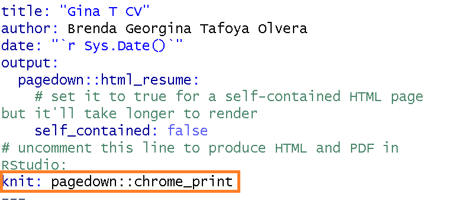